# Association rules

Nikhlesh Daga

2/22/2019

## Association rule

Also known as Market Basket analysis or Affinity analysis.

It is a rule based machine learning algorithm which can help us identify correlations between different transactions using certain measures. It can enable us to predict the occurrence of a particular item with another item or set of items based on past transactions. The rules can be created by tracking the baskets of various customers while they are checking in and can be used to predict future buying trends, creating optimal bundles/offers, product placement decisions, pricing decisions etc.

## Required packages

```r
library(arules)
```

```r
library(arulesViz)
library(datasets)
```

## Read in the data

We would be using the Groceries data which comes with R

```r
# Groceries data
data('Groceries') #different format - transaction format
arules::inspect(Groceries[1:5])
```

```
##     items
## [1] {citrus fruit,
##      semi-finished bread,
##      margarine,
##      ready soups}
## [2] {tropical fruit,
##      yogurt,
##      coffee}
## [3] {whole milk}
## [4] {pip fruit,
##      yogurt,
##      cream cheese ,
##      meat spreads}
## [5] {other vegetables,
##      whole milk,
##      condensed milk,
##      long life bakery product}
```

```r
# Cosmetics data
df<-read.csv("Cosmetics.csv",header=TRUE, sep=",")
head(df)
```

```
##   Trans. Bag Blush Nail.Polish Brushes Concealer Eyebrow.Pencils Bronzer
## 1      1   0     1           1       1         1               0       1
## 2      2   0     0           1       0         1               0       1
## 3      3   0     1           0       0         1               1       1
## 4      4   0     0           1       1         1               0       1
## 5      5   0     1           0       0         1               0       1
## 6      6   0     0           0       0         1               0       0
##   Lip.liner Mascara Eye.shadow Foundation Lip.Gloss Lipstick Eyeliner
## 1         1       1          0          0         0        0        1
## 2         1       0          0          1         1        0        0
## 3         1       1          1          1         1        1        0
## 4         0       0          0          1         0        0        1
## 5         1       1          1          0         1        1        0
## 6         0       0          0          0         0        0        1
```

Few quick definitions -

1. **Support** - number of times(or percent of times) the antecedent(if) and the consequent(then) occur together. Can be used to consider only the combinations which occur atleast a certain number of times or with higher frequency.
2. **Confidence** - percent of antecedent(if) transactions that also have the consequent(then) item set or P(C|A) = p(C and A)/P(A) or number of transactions with both antecedent and consequent/number of transactions with antecedent items
3. **Lift ratio** - We can get higher confidence numbers just because of items which are essentially just picked up without any relevance with other items being picked e.g. milk, bread etc. Lift ratio is defined as lift(x->y) = support(x and y)/(support(x) * support(y))

Lift ratio greater than 1 is a good sign of association.

Let’s look at a smaller dataset and calculation for these parameters for better understanding.

Apriori function is used to calculate rules

```r
rules = apriori(as.matrix(df[,2:15]), parameter=list(support=0.15, confidence=0.65,minlen=2))
```

```
## Apriori
##
## Parameter specification:
##  confidence minval smax arem  aval originalSupport maxtime support minlen
##        0.65    0.1    1 none FALSE            TRUE       5    0.15      2
##  maxlen target   ext
##      10  rules FALSE
##
## Algorithmic control:
##  filter tree heap memopt load sort verbose
##     0.1 TRUE TRUE  FALSE TRUE    2    TRUE
##
## Absolute minimum support count: 150
##
## set item appearances ...[0 item(s)] done [0.00s].
## set transactions ...[14 item(s), 1000 transaction(s)] done [0.00s].
## sorting and recoding items ... [11 item(s)] done [0.00s].
## creating transaction tree ... done [0.00s].
## checking subsets of size 1 2 3 done [0.00s].
## writing ... [19 rule(s)] done [0.00s].
## creating S4 object  ... done [0.00s].
```

```r
rulesc <- sort (rules, by="confidence", decreasing=TRUE)
inspect(rulesc[1:5])
```

```
##     lhs                       rhs          support confidence lift
## [1] {Blush,Eye.shadow}     => {Mascara}    0.169   0.9285714  2.601040
## [2] {Blush,Mascara}        => {Eye.shadow} 0.169   0.9184783  2.410704
## [3] {Mascara}              => {Eye.shadow} 0.321   0.8991597  2.359999
## [4] {Concealer,Eye.shadow} => {Mascara}    0.179   0.8905473  2.494530
## [5] {Concealer,Mascara}    => {Eye.shadow} 0.179   0.8774510  2.303021
##     count
## [1] 169
## [2] 169
## [3] 321
## [4] 179
## [5] 179
```

**Support** The support for first rule is 0.169. If we look at the data, there are 169 transactions out of total 1000 transactions which include Blush, Eye Shadow and Mascara, so the support is calculated as 169/1000.

**Lift Ratio** The lift ratio for the first rule is 2.601040. Lift ratio can be defined as

(support for Blush, Eye Shadow and Mascara)/support for Blush and Eye Shadow) * (support for Mascara)

On calculating this will come down to (169/(182 * 357)) * 1000

## How To Control The Number Of Rules in Output?

```r
frequentItems = eclat (Groceries, parameter = list(supp = 0.01, minlen= 2, maxlen = 5))
```

```
## Eclat
##
## parameter specification:
##  tidLists support minlen maxlen            target   ext
##     FALSE    0.01      2      5 frequent itemsets FALSE
##
## algorithmic control:
##  sparse sort verbose
##       7   -2    TRUE
##
## Absolute minimum support count: 98
##
## create itemset ...
## set transactions ...[169 item(s), 9835 transaction(s)] done [0.00s].
## sorting and recoding items ... [88 item(s)] done [0.00s].
## creating sparse bit matrix ... [88 row(s), 9835 column(s)] done [0.00s].
## writing  ... [245 set(s)] done [0.01s].
## Creating S4 object  ... done [0.00s].
```

```r
inspect(sort (frequentItems, by="count", decreasing=TRUE)[1:25])
```

```
##      items                                 support    count
## [1]  {other vegetables,whole milk}         0.07483477 736
## [2]  {whole milk,rolls/buns}               0.05663447 557
## [3]  {whole milk,yogurt}                   0.05602440 551
## [4]  {root vegetables,whole milk}          0.04890696 481
## [5]  {root vegetables,other vegetables}    0.04738180 466
## [6]  {other vegetables,yogurt}             0.04341637 427
## [7]  {other vegetables,rolls/buns}         0.04260295 419
## [8]  {tropical fruit,whole milk}           0.04229792 416
## [9]  {whole milk,soda}                     0.04006101 394
## [10] {rolls/buns,soda}                     0.03833249 377
## [11] {tropical fruit,other vegetables}     0.03589222 353
## [12] {whole milk,bottled water}            0.03436706 338
## [13] {yogurt,rolls/buns}                   0.03436706 338
## [14] {whole milk,pastry}                   0.03324860 327
## [15] {other vegetables,soda}               0.03274021 322
## [16] {whole milk,whipped/sour cream}       0.03223183 317
## [17] {sausage,rolls/buns}                  0.03060498 301
## [18] {citrus fruit,whole milk}             0.03050330 300
## [19] {pip fruit,whole milk}                0.03009659 296
## [20] {whole milk,domestic eggs}            0.02999492 295
## [21] {sausage,whole milk}                  0.02989324 294
## [22] {tropical fruit,yogurt}               0.02928317 288
## [23] {bottled water,soda}                  0.02897814 285
## [24] {other vegetables,whipped/sour cream} 0.02887646 284
## [25] {citrus fruit,other vegetables}       0.02887646 284
```

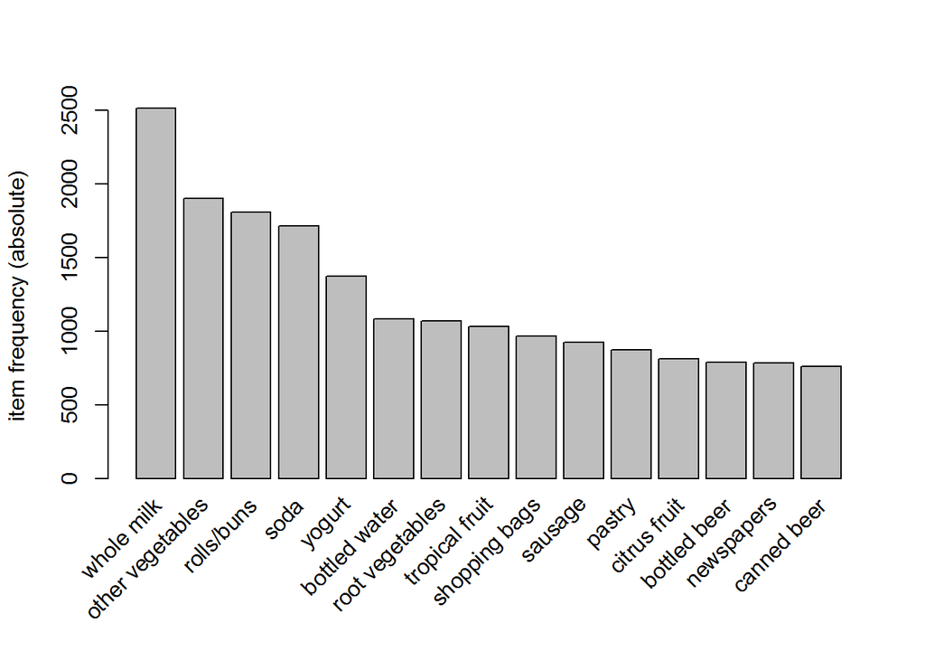

```r
itemFrequencyPlot(Groceries, topN = 15,type="absolute")
```

```r
rules2 = apriori (Groceries, parameter = list (supp = 0.001, conf = 0.5, minlen=2, maxlen=3))
```

```
## Apriori
##
## Parameter specification:
##  confidence minval smax arem  aval originalSupport maxtime support minlen
##         0.5    0.1    1 none FALSE            TRUE       5   0.001      2
##  maxlen target   ext
##       3  rules FALSE
##
## Algorithmic control:
##  filter tree heap memopt load sort verbose
##     0.1 TRUE TRUE  FALSE TRUE    2    TRUE
##
## Absolute minimum support count: 9
##
## set item appearances ...[0 item(s)] done [0.00s].
## set transactions ...[169 item(s), 9835 transaction(s)] done [0.00s].
## sorting and recoding items ... [157 item(s)] done [0.00s].
## creating transaction tree ... done [0.00s].
## checking subsets of size 1 2 3
```

```
##  done [0.00s].
## writing ... [1472 rule(s)] done [0.00s].
## creating S4 object  ... done [0.00s].
```

```r
rules2  #no of rules
```

```
## set of 1472 rules
```

```r
rules #earlier rules
```

```
## set of 19 rules
```

```r
inspect(rules2[1:15])
```

```
##      lhs                               rhs                support
## [1]  {honey}                        => {whole milk}       0.001118454
## [2]  {tidbits}                      => {rolls/buns}       0.001220132
## [3]  {cocoa drinks}                 => {whole milk}       0.001321810
## [4]  {pudding powder}               => {whole milk}       0.001321810
## [5]  {cooking chocolate}            => {whole milk}       0.001321810
## [6]  {cereals}                      => {whole milk}       0.003660397
## [7]  {jam}                          => {whole milk}       0.002948653
## [8]  {specialty cheese}             => {other vegetables} 0.004270463
## [9]  {rice}                         => {other vegetables} 0.003965430
## [10] {rice}                         => {whole milk}       0.004677173
## [11] {baking powder}                => {whole milk}       0.009252669
## [12] {liver loaf,yogurt}            => {whole milk}       0.001016777
## [13] {tropical fruit,curd cheese}   => {other vegetables} 0.001016777
## [14] {curd cheese,rolls/buns}       => {whole milk}       0.001016777
```

[output cut: 17 more lines]